# CHAPTER A25

# 弾性および熱弾性の2次元方程式

## A25.1 導入

関心のある点における応力成分がすべて1つの平面内にあり、物体自体または外力荷重の対称性によって、物体全体の応力がすべてこの1つの平面内にあるような弾性体においては、応力解析は2次元となる。この平面に垂直なすべての応力はゼロである。このとき、この解析は平面応力（plane stress）状態のものと呼ばれる。

同様に、すべてのひずみが1つの平面内にある（平面に垂直なすべてのひずみ成分がゼロである）場合、問題はやはり2次元であり、その解析は平面ひずみ（plane strain）状態のものと呼ばれる。

平面への制限は、もちろん必須ではなく、応力またはひずみの2次元問題の定義は、基準軸の1つに平行な応力またはひずみ成分を無視することによって、一般的な3次元方程式を2次元形式に縮小できるものへと一般化されるべきである。

平面応力の方程式は平面ひずみの方程式とは異なるため、以下の展開において、それぞれが順次取り扱われる。

以下の展開では、熱弾性の方程式が導出され、議論される。弾性方程式は、温度 $T$ を含むすべての項を削除することによって直接導かれる。

## A25.2 平面応力

説明の目的上、議論はシステムがデカルト座標系によって最もよく定義されるような幾何学的形状を持つ物理的問題に限定される。円柱座標系または球座標系によって定義されるシステムへの拡張は、直接的に行われる。

上記の制限のもとで、平面応力問題は、軸の1つに平行なすべての応力成分がゼロであることを要求する。この軸を $z$ 軸とする。そのとき、

$$\sigma_z = \tau_{xz} = \tau_{yz} = 0
\qquad (25.1)$$

は、平面応力状態を完全に定義する方程式である。この方程式が適用される単純な一例は、表面に荷重がなく、拘束されておらず、図 A25.1 に示されているように厚さ方向に温度が変化しない薄い板（slice）である。厚さ方向に温度変化のない薄い片持ち翼は、この記述を満たす物理システムであり、単純な片持ち梁の等温問題も同様である。これら両方の例は、第 A26 章でかなり詳しく議論される。

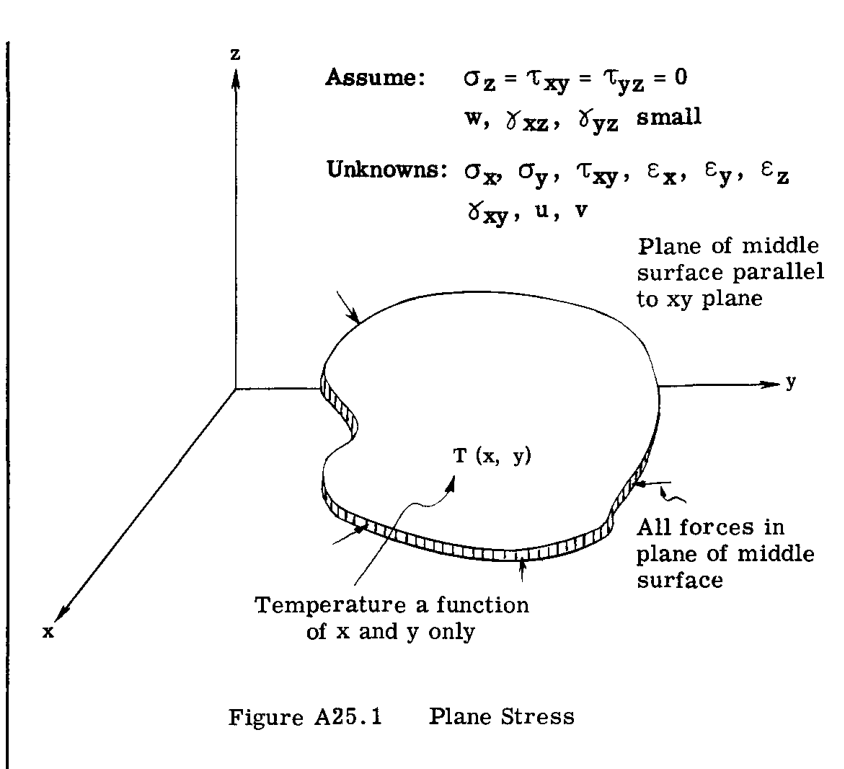

Plane Stress

方程式 25.1 において、未知数は以下のように減少する。

$$\begin{matrix}
\sigma_x & \epsilon_x & u \\
\sigma_y & \epsilon_y & v \\
\tau_{xy} & \gamma_{xy}
\end{matrix}$$

（ $w$ は無視できるほど小さいと仮定されるため、 $w$ が少しでも存在する場合には、結果は近似的なものにならざるを得ない。）

ここで、2つの変位成分 $u$ と $v$ のみが存在するという言明は、縁荷重が中間面に関して対称であり、平面外への曲げ変位が発生しない薄い板の仮定と一致する仮定である。平面応力定式化のためのこの要求される荷重の対称性は、薄い円筒殻や球殻の問題などのように、円柱座標系または球座標系で定義されるシステムにおいて慎重に考慮されなければならない。

一般解に必要な8つの方程式は、前章の方程式 25.1 を A24.7 の方程式群に代入することにより直接導出できる。

2つの釣合い方程式：

$$\frac{\partial\sigma_x}{\partial x} + \frac{\partial\tau_{xy}}{\partial y} + X = 0
\qquad (25.2)$$

$$\frac{\partial\sigma_y}{\partial y} + \frac{\partial\tau_{xy}}{\partial x} + Y = 0
\qquad (25.3)$$

3つの応力-ひずみ関係式は：

$$\gamma_{xy} = \frac{1}{G} \tau_{xy}
\qquad (25.6)$$

ここで、弾性問題に対しては $T = 0$ であり、3つのひずみ-変位関係式は、

$$\epsilon_x = \frac{\partial u}{\partial x}
\qquad (25.7)$$

$$\epsilon_y = \frac{\partial v}{\partial y}
\qquad (25.8)$$

$$\gamma_{xy} = \frac{\partial u}{\partial y} + \frac{\partial v}{\partial x}
\qquad (25.9)$$

この方程式群は一般解に対して完全である。応力定式化からの解の一意性のために必要なひずみ成分 $\epsilon_z$ の式と適合方程式が依然として必要である。 $\epsilon_z$ の式は、この方程式群の解から直接得られるため、通常は完成した方程式群には含まれず、次のように与えられる。

適合方程式は、ひずみで表すと次のようになる。

$$\frac{\partial^2\gamma_{xy}}{\partial x \partial y} = \frac{\partial^2\epsilon_x}{\partial y^2} + \frac{\partial^2\epsilon_y}{\partial x^2}
\qquad (25.11)$$

ここで、

$$X = Y = 0$$

であり、 $E$ と $\alpha$ は定数（温度や物体内の位置に依存しない）である。 $X = 0, Y = 0$ の場合についてはセクション A25.4 の注記を参照のこと。

境界条件：

第 A24 章からの境界条件方程式は、各ケースにおいて以下のように縮小される。

ケース 1：板の境界における応力境界条件

$$\begin{aligned}
\bar{X} &= \sigma_x l + \tau_{xy} m \\
\bar{Y} &= \sigma_y m + \tau_{xy} l \\
\bar{Z} &= 0
\end{aligned}
\qquad (25.14)$$

ここで、 $\bar{X}, \bar{Y}$ はそれぞれ $x$ および $y$ 方向の単位面積あたりの外表面力の成分である。

ケース 2：変位境界条件、および熱応力解析において通常 $\bar{X} = \bar{Y} = 0$ と仮定する場合。

$$\begin{aligned}
u &= f(s) \\
v &= g(s) \\
w &= 0
\end{aligned}
\qquad (25.15)$$

第 A24 章の議論はこれらの境界条件に適用され、必要に応じて再度学習されるべきである。この議論は、すべての表面をトラクションフリー（外力なし）として応力定式化において熱応力問題を処理し、その後、等温解析によって外力荷重の影響および規定された場所での熱変位の除去を決定する通常の手順を概説している。

## A25.3 方程式の導出

この主題が初めての人にとっては、このセクションで完全な方程式群をもう少し詳細に導出することが有益であろう。これらの導出は弾性力学の任意の教科書に見出すことができ、読者の便宜のためにのみここで繰り返されている。多くの2次元応力問題においては、選択されたファイバーの空間における考えられる変形という基本的な考慮からひずみ-変位関係を開発する必要があるため、ここに提示する最も単純なケースの開発に特別な注意を払う必要がある。

### 釣合い方程式

3次元物体から抽出された要素に対する正の応力成分が示されている第 A24 章に示されている図を考慮する。この図を $z$ 軸から正の $z$ 方向に見た場合、次の図が観察される。

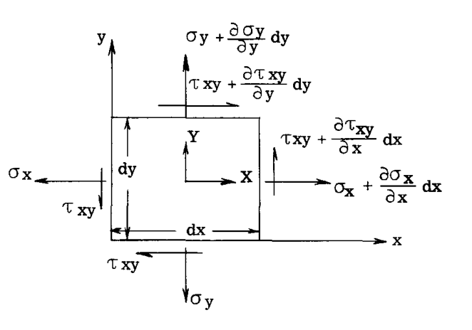

Stress Diagram

平面応力問題において、示されている応力成分は、定義によって $x-y$ 平面外の応力成分がゼロであるため、作用するすべてのものである。釣合い方程式は、図が実際には深さ $dz$ の3次元要素の平面図であることを覚えておき、この代数和をゼロに等しくすることによって、 $x$ および $y$ 方向の力を合計することによって容易に導出される。

$\sum F_y = 0$ を考慮する。

$$\left(\sigma_y + \frac{\partial\sigma_y}{\partial y} dy\right) dx dz - \sigma_y dx dz + \left(\tau_{xy} + \frac{\partial\tau_{xy}}{\partial x} dx\right) dy dz - \tau_{xy} dy dz + Y dx dy dz = 0$$

したがって、要素の体積 $dx dy dz$ で割り、相殺すると、

$$\frac{\partial\sigma_y}{\partial y} + \frac{\partial\tau_{xy}}{\partial x} + Y = 0$$

方程式 $\sum F_x = 0$ から、

$$\frac{\partial\sigma_x}{\partial x} + \frac{\partial\tau_{xy}}{\partial y} + X = 0$$

弾性材料が平衡状態にあるためには、応力成分の変動と体力（body forces）がこれらの方程式を満たさなければならない。

### 応力-ひずみ関係

弾性等温問題を考慮する。フックの法則の一般化された記述は、応力の各独立成分（ $\sigma_x, \sigma_y, \tau_{xy}$ ）がひずみ成分（ $\epsilon_x, \epsilon_y, \gamma_{xy}$ ）の線形関数として表され、またその逆も同様であることを規定している。したがって、次の数学的表現が従う。

$$\begin{aligned}
\sigma_x &= a_{11} \epsilon_x + a_{12} \epsilon_y + a_{13} \gamma_{xy} \\
\sigma_y &= a_{21} \epsilon_x + a_{22} \epsilon_y + a_{23} \gamma_{xy} \\
\tau_{xy} &= a_{31} \epsilon_x + a_{32} \epsilon_y + a_{33} \gamma_{xy}
\end{aligned}$$

現在、材料が等方性である場合、主応力の方向は主ひずみの方向でもあることが従う。主応力と主ひずみの間の関係は、次のように書くことができる。

$$\begin{aligned}
\sigma_1 &= a_{11} \epsilon_1 + a_{12} \epsilon_2 \\
\sigma_2 &= a_{21} \epsilon_1 + a_{22} \epsilon_2
\end{aligned}$$

行列形式では、これらの方程式は次のように書くことができる。

$$\begin{Bmatrix} \sigma_1 \\ \sigma_2 \end{Bmatrix} = \begin{bmatrix} a_{11} & a_{12} \\ a_{21} & a_{22} \end{bmatrix} \begin{Bmatrix} \epsilon_1 \\ \epsilon_2 \end{Bmatrix}$$

そしてクラメールの公式から、したがって次のように従う。

$$\epsilon_1 = \frac{\sigma_1 a_{22}}{a_{11}a_{22} - a_{21}a_{12}} - \frac{\sigma_2 a_{12}}{a_{11}a_{22} - a_{21}a_{12}}$$

および

$$\epsilon_2 = -\frac{\sigma_1 a_{21}}{a_{11}a_{22} - a_{21}a_{12}} + \frac{\sigma_2 a_{11}}{a_{11}a_{22} - a_{21}a_{12}}$$

再び、弾性体内の点における弾性的性質はすべての方向で同じであるという等方性の仮定から、主方向の添字は任意に規定できるため、添字の完全な入れ替えを行うことができる。したがって、次のように従う。

$$\begin{aligned}
a_{12} &= a_{21} \\
a_{11} &= a_{22}
\end{aligned}$$

定数

$$\frac{a_{11}}{a_{11}a_{22} - a_{21}a_{12}} = \frac{1}{E}$$

および定数

したがって、直接の伸びは単純な公式によって関連付けられ、そこでは9つの一般定数が2つに減少している。

しかしながら、一般的にそうであるように、座標方向が主方向でない場合、せん断応力とせん断ひずみが直接の伸びと同時に存在する。せん断ひずみは直接の伸びとは独立しており、関係によってせん断応力に関連付けられている。

$$\gamma_{xy} = \frac{1}{G} \tau_{xy}$$

ここで、次のように示される。

したがって、座標軸が主軸ではない一般的な場合において、応力とひずみを関連付ける2次元方程式は次のように書くことができる。

弾性体が加熱されると、考慮されている小さな要素は一様に膨張し、温度 $T$ による結果としての変形は、 $x$ および $y$ 方向の両方において、直接伸び $\alpha T$ （ $\alpha$ は線熱膨張係数）に等しくなることは明らかである。せん断ひずみ成分は影響を受けない。したがって、平面応力問題における熱弾性応力-ひずみ関係は、次のように書くことができる。

### ひずみ - 変位関係

弾性2次元物体内の点 $O$ を考慮する。外力荷重と温度差の影響下で、この点は変位成分 $u$ と $v$ を通じて新しい位置 $O'$ に変位する。第 A24 章で議論したように、変形後に点 $O$ の再定義が必要ないか、またはそれらの導関数の自乗や積が無視できるほど、これらの変位が十分に小さいということは、弾性力学の線形理論の必要な仮定である。ひずみ-変位関係は、選択された成分方向の方向に元々配向されていたファイバーの変形を考慮することによって導出される。

以下の図を考慮する。

[figure not shown]

Deformed Fiber

$$\begin{aligned}
u_1 &= u + \frac{\partial u}{\partial x} l dr + \frac{\partial u}{\partial y} m dr \\
v_1 &= v + \frac{\partial v}{\partial x} l dr + \frac{\partial v}{\partial y} m dr
\end{aligned}$$

ここで、 $l$ と $m$ はファイバーの方向余弦である。 $O$ の座標は $u$ と $v$ である。 $O_1$ の座標は $l dr$ と $m dr$ である。 $O'_1$ の座標は

$$\begin{aligned}
&l dr + u_1 \\
\text{および} \quad &m dr + v_1
\end{aligned}$$

したがって、変形したファイバーの $x$ 軸上への投影は次のように与えられる。

$$l dr + u_1 - u = l dr + \frac{\partial u}{\partial x} l dr + \frac{\partial u}{\partial y} m dr$$

そして $y$ 軸に沿っては次のように与えられる。

$$m dr + (v_1 - v) = m dr + \frac{\partial v}{\partial x} l dr + \frac{\partial v}{\partial y} m dr$$

直角三角形から、以下のように従う。

$$\begin{aligned}
(dr + \epsilon dr)^2 = &\left(l dr + \frac{\partial u}{\partial x} l dr + \frac{\partial u}{\partial y} m dr\right)^2 \\
&+ \left(m dr + \frac{\partial v}{\partial x} l dr + \frac{\partial v}{\partial y} m dr\right)^2
\end{aligned}$$

これは以下に導く。

$$\epsilon = l^2 \frac{\partial u}{\partial x} + m^2 \frac{\partial v}{\partial y} + lm \left(\frac{\partial u}{\partial y} + \frac{\partial v}{\partial x}\right)$$

$$l^2 + m^2 = 1$$
であるため。

したがって、変位の導関数が既知であれば、任意の与えられた配向のファイバーのひずみを見つけることができる。 $x$ 方向のひずみを考慮する。これは、元々 $x$ 軸に沿って整列していたファイバーを考慮することによって得られる。この場合、 $l = 1, m = 0$ であり、

$$\epsilon_x = \frac{\partial u}{\partial x}$$

同様に、 $y$ 方向のひずみは次のように与えられる。

$$\epsilon_y = \frac{\partial v}{\partial y}$$

$$\begin{aligned}
\gamma_{xy} &= \text{元の } 90^\circ \text{ の角度の減少} \\
&= \frac{\partial u}{\partial y} + \frac{\partial v}{\partial x}
\end{aligned}$$

ひずみ $\epsilon$ の一般式は、 $\epsilon_x, \epsilon_y$ および $\gamma_{xy}$ を用いて次のように書き直すことができることに注意すべきである。

$$\epsilon = l^2 \epsilon_x + m^2 \epsilon_y + lm \gamma_{xy}$$

これは、 $x-y$ 軸系に対してある角度で配向された切断面上の直接応力の式に正確に類似している。すなわち、

$$\sigma = l^2 \sigma_x + m^2 \sigma_y + 2lm \tau_{xy}$$

したがって、主応力の方向が主ひずみの方向と一致することは容易に検証される。

## A25.4 平面応力問題の定式化

**(a) 応力定式化** - すべての境界条件が表面力（表面トラクション）で与えられている場合。

2つの釣合い方程式は、3つの応力成分 $\sigma_x, \sigma_y, \tau_{xy}$ の観点からすでに書かれている。適合方程式は 25.12 で与えられる。したがって、3つの未知数 $\sigma_x, \sigma_y, \tau_{xy}$ によって満たされなければならない方程式は次のとおりである。

$$\left. \begin{aligned}
\frac{\partial\sigma_x}{\partial x} + \frac{\partial\tau_{xy}}{\partial y} &= 0 \\
\frac{\partial\sigma_y}{\partial y} + \frac{\partial\tau_{xy}}{\partial x} &= 0
\end{aligned} \right\}
\quad \text{体力が } X = Y = 0 \text{ のとき}
\qquad (25.16)$$

および、

$$\begin{aligned}
\frac{\partial^2\sigma_x}{\partial x^2} + \frac{\partial^2\sigma_x}{\partial y^2} + \frac{\partial^2\sigma_y}{\partial x^2} + \frac{\partial^2\sigma_y}{\partial y^2} + E\alpha \left(\frac{\partial^2 T}{\partial x^2} + \frac{\partial^2 T}{\partial y^2}\right) &= 0 \\
&= 0
\end{aligned}
\qquad (25.17)$$

$E$ と $\alpha$ の両方が温度 $T$ および物体内の位置から独立している場合。この応力で表された適合方程式の導出は、学生への練習問題として残されている。

この定式化における問題の具体的な解決には、上記3つの方程式および 25.14 の境界条件方程式を満たす $\sigma_x, \sigma_y$ および $\tau_{xy}$ の値が必要である。

$X = Y = 0$ （体力がない）のとき、またはこれらの体力をポテンシャル関数 $V$ によって以下のように表すことができるとき、

$$X = -\frac{\partial V}{\partial x}, \quad Y = -\frac{\partial V}{\partial y}
\qquad (25.18)$$

逆解法（inverse solution technique）が通常最も有益であることを証明する。弾性および熱弾性の線形問題においては、応力定式化が最も頻繁に発生するため、この逆アプローチはここでいくつかの詳細に説明されている。このアプローチは、現在議論されている平面応力問題に限定されず、平面ひずみやその他の2次元応力定式化にも同様に適用できる。

一般に、関係式によって定義される応力関数 $\phi$ を選択することができる。

$$\begin{aligned}
\sigma_x &= \frac{\partial^2\phi}{\partial y^2} \\
\sigma_y &= \frac{\partial^2\phi}{\partial x^2} \\
\tau_{xy} &= -\frac{\partial^2\phi}{\partial x \partial y}
\end{aligned}
\qquad (25.19)$$

この関数 $\phi$ は、エアリー（Airy）がこのよく知られた数学的手法を弾性力学の問題に最初に適用したため、一般にエアリーの応力関数（Airy stress function）と呼ばれる。

$X = Y = 0$ のとき。

および、

であり、 $E$ と $\alpha$ は温度の関数ではない。 $\phi$ の一般解は、与えられた温度分布に対して 25.20 または 25.21 を解くことによって得られる。応力の一般解は 25.19 から直接得られる。具体的な解は、境界条件 25.14 への代入によって得られる。

境界条件がトラクションフリー（外力なし）の境界条件であるこのケースでは、方程式 25.14 は $\phi$ の観点から次のように書くことができる。

$$\phi = 0$$

$$\text{および} \quad \frac{\partial\phi}{\partial n} = 0
\qquad (25.22)$$

ここで $n$ は境界上のすべての点における外向き法線である。したがって、具体的な解は $\phi$ の観点から直接得ることができ、 $\sigma_x, \sigma_y$ および $\tau_{xy}$ の具体的な解は 25.19 への直接代入によって得られる。

を満たし、かつ体力が存在しない場合、熱応力はまったく存在しないことに注意すべきである。したがって、 $T$ が定数または $x$ と $y$ の線形関数である場合、熱応力は発生しない。

この時点で、円柱座標に対する応力関数の定義を提示することは便利である（ 25.19 に等価であり、 $z$ を軸方向として $x-y$ 平面から $r-\theta$ 平面への単純な変換によってそこから得られる）。

$$\begin{aligned}
r^2 &= x^2 + y^2 \\
\theta &= \tan^{-1}\left(\frac{y}{x}\right)
\end{aligned}$$

そして、一般解が得られる適合方程式（体力がゼロと見なされる場合の Equation 25.20 に等価）。

応力関数 $\phi$ は、次の式によって定義される。

$$\begin{aligned}
\sigma_r &= \frac{1}{r} \frac{\partial\phi}{\partial r} + \frac{1}{r^2} \frac{\partial^2\phi}{\partial\theta^2} \\
\sigma_\theta &= \frac{\partial^2\phi}{\partial r^2} \\
\tau_{r\theta} &= \frac{1}{r^2} \frac{\partial\phi}{\partial\theta} - \frac{1}{r} \frac{\partial^2\phi}{\partial r \partial\theta} \\
&= -\frac{\partial}{\partial r} \left(\frac{1}{r} \frac{\partial\phi}{\partial\theta}\right)
\end{aligned}$$

そして適合方程式は次のようになる。

$$\begin{aligned}
\left(\frac{\partial^2}{\partial r^2} + \frac{1}{r} \frac{\partial}{\partial r} + \frac{1}{r^2} \frac{\partial^2}{\partial\theta^2}\right) \left(\frac{\partial^2\phi}{\partial r^2} + \frac{1}{r} \frac{\partial\phi}{\partial r} + \frac{1}{r^2} \frac{\partial^2\phi}{\partial\theta^2}\right) = \\
- E\alpha \left(\frac{\partial^2 T}{\partial r^2} + \frac{1}{r} \frac{\partial T}{\partial r} + \frac{1}{r^2} \frac{\partial^2 T}{\partial\theta^2}\right)
\end{aligned}$$

3次元ケースから2次元平面応力問題へのこの縮小は、方程式

$$\tau_{xz} = \tau_{yz} = 0
\qquad (25.24)$$

を上表面および下表面で採用することにより、プレートまたはスライスの厚さ $t$ 方向に温度が変化するケースを含む等価な問題に一般化することができる。これらの方程式は 25.1 に類似している。この方程式は、応力成分、温度、変位、および縁荷重が厚さ方向の平均値として捉えられることを要求している。たとえば、温度は次のように書かれる。

$$T = \int_{-t/2}^{+t/2} T dz$$

量 $\tau_{xz}, \tau_{yz}, \gamma_{xz}, \gamma_{yz}$ および $w$ は、無視できるほど厚さ方向に十分に小さくなければならない。これは厳密な平面応力問題ではなく、第 A26 章で示されるように、その適用には注意が必要である。結果は、厚さ方向の $\sigma_x, \sigma_y, \gamma_{xy}, \epsilon_x, \epsilon_y, u, v$ の平均値となる。

**(b) 変位定式化** - 境界条件が境界変位で与えられている場合。変位定式化を選択することにより、適合方程式は自動的に満たされる。2つの変位 $u$ と $v$ の一般解は、変位の観点から書かれた2つの釣合い方程式から次のように得られる。

ここで、再び $E, \alpha$ および $u$ は定数である。これらの方程式は、方程式 25.4, .5, .6, .7, .8 および .9 を方程式 25.2 および .3 に直接代入することによって導出される。

具体的な解は、一般解を境界条件方程式 25.15 に代入し、未知の定数を解くことによって得られる。

## A25.5 平面ひずみ

平面ひずみ問題は、座標軸方向の1つ、たとえば $z$ 方向、に変位が存在しないことを要求する。したがって、 $w = 0$ であり、 $u$ と $v$ は $x$ と $y$ のみの関数である。これは、次のひずみ成分がゼロであることを要求することと等価である。

$$\epsilon_z = \gamma_{xz} = \gamma_{yz} = 0
\qquad (25.26)$$

8つの未知数は $\sigma_x, \sigma_y, \tau_{xy}, \gamma_{xy}, \epsilon_x, \epsilon_y, u$ および $v$ になる。この平面ひずみのケースでは、 $\sigma_z$ は $\sigma_x$ と $\sigma_y$ の関数になり、したがって、未知数としては考慮されない。 25.26 を A24 の15個の方程式に代入すると、独立した方程式の数は8つに減少する（2つの釣合い方程式、3つの応力-ひずみ関係、および3つのひずみ-変位関係）。したがって、方程式群は完全である。

$w = 0$ 、すなわち $x-y$ 平面に垂直な変位が存在しないという条件は、元々 $x-y$ 平面内にあった任意の切断面が変形後もこの平面に平行なままであることを要求する。このような状況が存在する物理システムの一例は、 $z$ 方向、すなわち軸方向の成分に依存しない外力荷重と温度を受け、すべての荷重と体力が軸方向に垂直に作用する（すなわち、すべての荷重が $x-y$ 平面内にあり、物体内の軸方向の位置に依存しない）長い円筒形物体である。このようなシステムは、ミサイルやロケット（円筒形のシェル本体、固体燃料グレイン、ロケットノズル）、原子力反応炉（円筒形燃料棒、熱交換器チューブ）などに一般的である。

解析対象のシステムを平面応力のものと見なすことができるか、または平面ひずみのものと見なすことができるかという問題は頻繁に提起され、この時点で回答されるべきである。システムを注意深く検討し、どちらか一方の状態に関連するすべての要件が満たされているかどうかを確認する必要がある。満たされていない場合、問題は本質的に3次元的なものであり、15個の方程式群を採用しなければならない。しかしながら、いくつかのケースにおいて、この決定は明確なものではない。たとえば、長さ $h$ 、直径 $b$ の有限長さの円筒殻を考慮し、その軸に垂直に荷重がかけられ、体力はゼロであり、温度は軸座標から独立しているとする。長さと直径の比 $h/b$ を考慮すると、問題は以下のように分類できる。

$$\begin{aligned}
\frac{h}{b} &\gg 1 \quad \text{平面ひずみ} \\
\frac{h}{b} &\ll 1 \quad \text{平面応力} \\
\frac{h}{b} &\approx 1 \quad \text{3次元}
\end{aligned}$$

実際には、平面応力問題は3次元ひずみ問題であり、平面ひずみ問題は、前者における $\epsilon_z$ の存在および後者における $\sigma_z$ の存在の可能性により、応力において3次元の問題であることに注意すべきである。

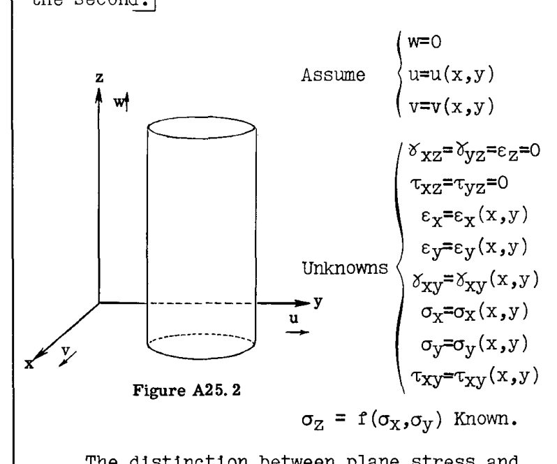

Plane Strain

平面応力問題と平面ひずみ問題の区別は、図 25.1 と 25.2 の比較によって明確に描かれている。

25.26 を第 A24 章の一般方程式に直接代入することにより、平面ひずみ問題の以下の8つの方程式が得られる。

2つの釣合い方程式：

$$\frac{\partial\sigma_x}{\partial x} + \frac{\partial\tau_{xy}}{\partial y} + X = 0
\qquad (25.27)$$

$$\frac{\partial\tau_{xy}}{\partial x} + \frac{\partial\sigma_y}{\partial y} + Y = 0
\qquad (25.28)$$

3つの応力-ひずみ関係（ $\epsilon_z = 0$ のとき）：

3つのひずみ-変位関係：

$$\epsilon_x = \frac{\partial u}{\partial x}
\qquad (25.32)$$

$$\epsilon_y = \frac{\partial v}{\partial y}
\qquad (25.33)$$

$$\gamma_{xy} = \frac{\partial u}{\partial y} + \frac{\partial v}{\partial x}
\qquad (25.34)$$

### 境界条件

第 A24 章からの境界条件方程式は、各ケースにおいて以下のように縮小される。

ケース 1：応力境界条件

$$\begin{aligned}
\bar{X} &= \sigma_x l + \tau_{xy} m \\
\bar{Y} &= \sigma_y m + \tau_{xy} l
\end{aligned}
\qquad (25.35)$$

この平面ひずみ問題においては、解から、次のように与えられる自由端における見かけの表面力が生じる。

これはもちろん非ゼロであり、したがって、この境界条件はトラクションフリー（外力なし）表面の仮定のもとでは満たされず、これが規定された適用表面力と一致することは極めて稀な偶然にすぎない。この見かけの表面力は、等温解析から導出される結果である同等かつ反対の表面力を適用することによって除去され、熱応力解析に重ね合わされなければならない。もし表面力がこれと他の表面全体に規定されている場合、結果として得られる応力、ひずみ、および変位成分のさらなる等温解析が実行され、実際的な解を得るために前の解に重ね合わされる。

この問題は、 $\sigma_z$ が完全な方程式群の解によって規定されるという事実に起因する。同様の問題は、もし表面ひずみが境界条件として規定された場合（もちろん、決して行われないが）、平面応力問題において発生するであろう。

ケース 2：変位境界条件

境界条件方程式は次のようになる。

$$\begin{aligned}
u &= f(s) \\
v &= g(s)
\end{aligned}
\qquad (25.36)$$

そして、3番目の変位 $w$ は、これが平面ひずみ問題の支配方程式であったため、ゼロでなければならない。

ケース 3：混合境界条件

表面力（トラクション）が表面の一部で規定され、変位が残りの部分で規定されている場合、適宜ケース1とケース2の方程式が適用されなければならない。

しかしながら、線形熱弾性解析は通常、すべての表面が拘束されておらずトラクションフリーであると仮定した熱応力解析に分解され、この部分の結果に、外力荷重の影響と規定された境界変位の充足を考慮した等温解析が重ね合わされることを、強調のためにここで繰り返しておく。

## A25.6 平面応力問題と平面ひずみ問題の数学的等価性

ひずみ-応力方程式 25.29, 25.30 および 25.31 は次のように書くことができる。

これらの方程式は、平面応力問題における同一の関係式 25.4, 25.5, 25.6 とまったく同じ形式である。実際、これら2つの方程式群は、上記のように弾性定数が変更されることを除いて、現在は同一である。したがって、数学的問題は本質的に同一であり、その結果、数学的定式化に関するセクション A25.4 の議論は、読者が弾性定数 $E, u$ および $\alpha$ を $E_1, u_1$ および $\alpha_1$ に変更する限り、この平面ひずみ問題に直接適用可能である。混乱を避けるために、これらの議論はここで簡潔に繰り返され、関連する方程式が書き直されている。

## A25.7 平面ひずみ問題の定式化

前述のケースと同様に、平面ひずみ問題は応力または変位の観点から定式化することができる。

**(a) 応力定式化**

3つの応力成分 $\sigma_x, \sigma_y$ および $\tau_{xy}$ によって満たされなければならない方程式は次のとおりである。

$$\left. \begin{aligned}
\frac{\partial\sigma_x}{\partial x} + \frac{\partial\tau_{xy}}{\partial y} + X &= 0 \\
\frac{\partial\sigma_y}{\partial y} + \frac{\partial\tau_{xy}}{\partial x} + Y &= 0
\end{aligned} \right\}
\quad \text{釣合い}
\qquad (25.39)$$

ここで、 $E, u$ および $\alpha$ は定数であり、一般解に対して、また具体的な解に対して、先ほど議論した境界条件である。

の解のみを必要とする。

**(b) 変位定式化**

このケースにおいても、一般解のためには変位の観点から表された釣合い方程式のみが満たされなければならない。これら2つの釣合い方程式は次のとおりである。

具体的な解は、今議論した境界条件方程式を使用することによって得られる。

## A25.8 結びの議論

今提示した平面応力と平面ひずみの2次元定式化は、設計応力解析者が対処しなければならない構造システムの大部分に適用される。しかしながら、応力、ひずみ、および変位成分が、平面応力および平面ひずみの理想化によって課される制限に従うことが明らかではない、加熱された構造形状が生じる。そのような場合には、3次元熱弾性の一般方程式を採用しなければならない。これらの方程式は、適切な応力、ひずみ、および変位成分をゼロまたは無視できると仮定することにより、可能な限り単純化されるべきである。このようなすべての問題において、拘束されておらずトラクションフリーである境界条件の仮定のもとで熱応力解析を調査し、外力荷重の影響と境界変位拘束の評価を等温解析に委ねることが推奨される。このアプローチは、回転シェルの熱弾性解析が議論される後半の章で説明される。

## A25.9 問題

が、方程式

$$\frac{\partial^2\gamma_{xy}}{\partial x \partial y} = \frac{\partial^2\epsilon_x}{\partial y^2} + \frac{\partial^2\epsilon_y}{\partial x^2}$$

から従うことを証明せよ。

2. セクション A25.3 の応力図から、釣合い方程式

$$\begin{aligned}
\frac{\partial\sigma_x}{\partial x} + \frac{\partial\tau_{xy}}{\partial y} + X &= 0 \\
\frac{\partial\sigma_y}{\partial y} + \frac{\partial\tau_{xy}}{\partial x} + Y &= 0
\end{aligned}$$

を導出せよ。

3. 逆解法について、ゼロ表面力の条件が応力関数 $\phi$ の観点から次のように書けることを確立せよ。

$$\phi = 0$$

$$\frac{\partial\phi}{\partial n} = 0$$

ここで $n$ は外向き法線である。

4. 円柱座標における釣合い方程式が次のように与えられることを証明せよ。

$$\begin{aligned}
\frac{\partial\sigma_r}{\partial r} + \frac{1}{r} \frac{\partial\tau_{r\theta}}{\partial\theta} + \frac{\sigma_r - \sigma_\theta}{r} &= 0 \\
\frac{1}{r} \frac{\partial\sigma_\theta}{\partial\theta} + \frac{\partial\tau_{r\theta}}{\partial r} + \frac{2\tau_{r\theta}}{r} &= 0
\end{aligned}$$

によって与えられることを証明せよ。ここで $r-\theta$ 平面は $x-y$ 平面に対応し、体力は存在しない。

6. 本文に示されている平面応力適合方程式を確立し、弾性定数を直接代入することにより、平面ひずみ熱弾性問題の適合方程式を書け。 25.18 で定義されている関数 $V$ から導出可能な体力 $X$ と $Y$ の存在を含めるように、これら両方の方程式を修正せよ。
7. 半径方向のみに作用し、 $\theta$ に独立な体力 $R$ が次のように定義される場合、

$$R = \sqrt{X^2 + Y^2}$$

ここで $X$ と $Y$ はそれぞれ $x$ および $y$ 方向の体力であり、次のように定義される。

$$\begin{aligned}
X &= -\frac{\partial V}{\partial x} \\
Y &= -\frac{\partial V}{\partial y}
\end{aligned}$$

デカルト座標から円柱座標への単純な変換から、次のように示されることを証明せよ。

$$R = -\frac{\partial V}{\partial r}$$

そしてしたがって、この特別なケースにおいて、釣合い方程式は次のようになる。

$$\begin{aligned}
\frac{\partial\sigma_r}{\partial r} + \frac{1}{r} \frac{\partial\tau_{r\theta}}{\partial\theta} + \frac{\sigma_r - \sigma_\theta}{r} + \frac{\partial V}{\partial r} &= 0 \\
\frac{1}{r} \frac{\partial\sigma_\theta}{\partial\theta} + \frac{\partial\tau_{r\theta}}{\partial r} + \frac{2\tau_{r\theta}}{r} &= 0
\end{aligned}$$

## 参考文献

1. “Elasticity in Engineering” E. E. Sechler, Galcit Aeronautical Series, John Wiley & Sons, Inc., 1952.
2. “Applied Elasticity” Chi-Teh Wang, McGraw-Hill Book Co., Inc., 1953.
3. 第 A24 章のすべての参考文献。